# Student Exam Performance Analysis Using Linear Regression

2026-03-20

```r
# Load dataset
data <- read.csv("~/Downloads/StudentPerformanceFactors.csv")

# Convert categorical variables to factors
data[] <- lapply(data, function(x) {
  if(is.character(x)) as.factor(x) else x
})
```

## Task Definition

The objective of this study is to predict student exam scores using a set of explanatory variables related to academic behavior, lifestyle and socioeconomic background. The predictors or independent variables are study habits, attendance, prior performance and demographic factors. The target or dependent variable is exam score, which is a continuous variable meaning it is numeric. This is an area of importance to study since academic performance is not affected by a single factor in isolation, rather it is likely affected by many differing outside forces. And because of that finding these predictor coefficients can help students have greater success on their exams. This can lead to students gain better career prospects, personal development and a better quality of life in the future.

## Model Definition

A multiple linear regression model was used to estimate the relationship between predictors and exam score. Linear regression is a statistical method used to model the relationship between a continuous outcome variable and one or more predictor variables. It assumes a linear relationship between predictors and the response, independence of observations, constant variance of errors and normally distributed errors. Categorical variables were converted into numeric variables to allow the model to estimate their effects through dummy variables compatible with linear regression. Linear regression was chosen because the target variable (exam score) is continuous and the goal is to model linear relationships between predictors and outcomes. RMSE, R² and MAE were selected as evaluation metrics because they capture both prediction error magnitude and explained variance, providing a comprehensive assessment of model performance. Linear regression models the relationship as: Exam_Score = β₀ + β₁X₁ + β₂X₂ + … + βₙXₙ + ε

Where: Xi are predictor variables (attendance, hours studied and prior academic performance) βi are coefficients (what the model will estimate given the data) ϵ is the error term (natural variability that may occur)

The modeling process used in this analysis was performed in this order: Input the dataset containing student characteristics and exam scores. Identify the target variable (Exam_Score) and predictor variables. Convert categorical variables into numerical representations using dummy variables compatible with linear regression. Split the dataset into training and testing subsets. Fit a linear regression model on the training data by estimating coefficients that minimize the sum of squared errors between predicted and actual exam scores. Use the trained model to generate predictions on the test dataset. Evaluate model performance using metrics such as RMSE, R² and MAE. Apply k-fold cross-validation to assess the stability and generalization of the model. Compare model performance across different specifications (full vs. reduced model).

## Methodology

### Evaluation Criteria

The model was evaluated using: - RMSE (Root Mean Squared Error) -measures prediction error (Investopedia) - R² (Coefficient of Determination) - proportion of explained variance (Investopedia) - MAE (Mean Absolute Error) -average magnitude of the errors (Investopedia) These metrics were selected because they provide complementary measures of predictive accuracy for regression problems.

### Variables

The total variables are hours studied, attendance, sleep hours, family income, parental education level, teacher quality, school type, distance from home, previous scores, tutoring sessions, motivation level, access to resources, parental involvement, peer influence, internet access, physical activity, learning disabilities and exam score. These variables were selected based on theoretical relevance to academic performance, including study habits, prior achievement and environmental factors known to influence learning outcomes.

### Hypothesis

I hypothesize that attendance and study time will have the greatest positive impact on exam scores. I also hypothesize that prior academic performance will be a strong predictor of high exam scores. Finally, I hypothesize that demographic variables such as gender and school type will have weaker but still have an observable effect on exam scores.

### Data

The dataset contains 6,607 observations and 19 predictors, including both numeric and categorical variables. (Grandmaster07, Kaggle) No missing values were present. A 70/30 train-test split was used to balance model training and unbiased evaluation on unseen data. Cross-validation was applied to reduce variance in performance estimates and ensure model robustness.

### Baseline and Reduced Model Comparison

Two models were compared: a full regression model (all predictors) and a reduced model (significant predictors only). This comparison evaluates whether simpler models perform comparably. The full regression model included all predictors. Specifically, the model included hours studied, attendance, sleep hours, family income, parental education level, teacher quality, school type, distance from home, previous scores, tutoring sessions, motivation level, access to resources, parental involvement, peer influence, internet access, physical activity and learning disabilities The baseline model was specified using all available predictors to establish a comprehensive benchmark for model performance. This approach allows for evaluation of the full set of academic, behavioral and socioeconomic variables before introducing model simplification. The reduced model included predictors selected based on theoretical relevance and empirical performance. These variables represent key academic, behavioral and environmental factors expected to influence exam performance. Specifically, the model included hours studied, attendance, previous scores, tutoring sessions, motivation level, access to resources, parental involvement, peer influence, internet access, physical activity and learning disabilities.

### Presentation / Data Visualization

The data will be presented using scatterplots histograms and boxplots. They will help to visualize distribution, skewness and whether the data is a good fit for linear regression. Correlation matrices and heat maps were used to find which variables correlated most with exam scores. I also used boxplots to check for collinearity.

## Results

### Exploratory Data Analysis

Correlation analysis showed Attendance (r = 0.58) and Hours_Studied (r = 0.45) had the strongest relationships with Exam_Score. Whereas Sleep_Hours and Physical_Activity showed negligible correlation.

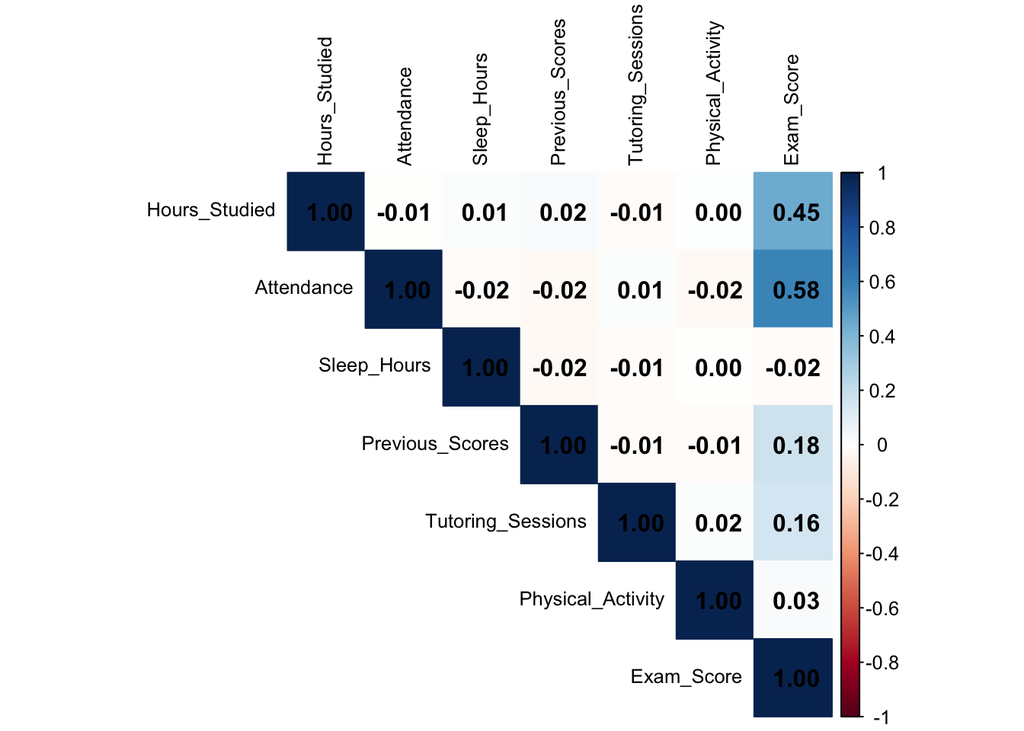

```r
# Load library
library(corrplot)
# Create correlation matrix (numeric variables only)
cor_matrix <- cor(data[, sapply(data, is.numeric)])

# Plot heatmap
corrplot(cor_matrix,
         method = "color",
         type = "upper",
         tl.cex = 0.8,
         tl.col = "black",
         addCoef.col = "black")
```

This was demonstrated through a heat map.

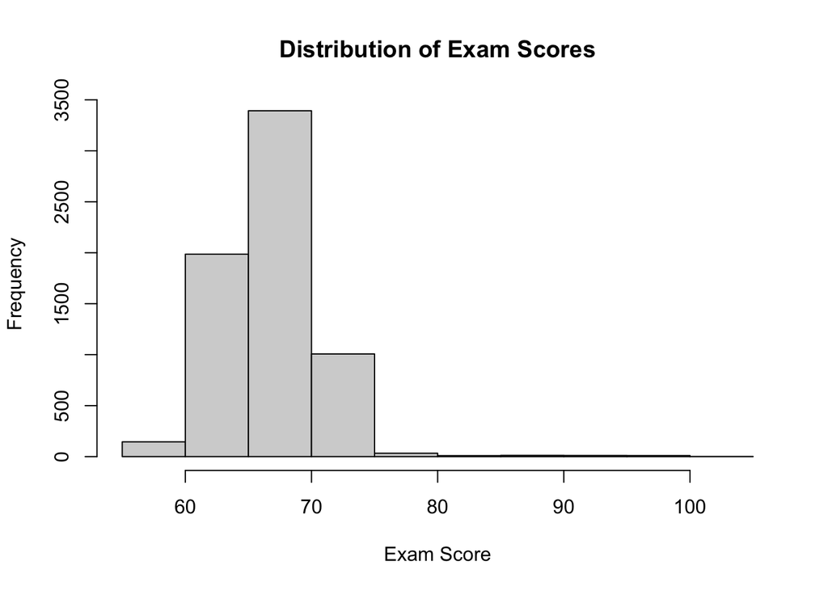

```r
hist(data$Exam_Score,
     main = "Distribution of Exam Scores",
     xlab = "Exam Score")
```

Histograms showed slight skew in data distribution.

# Scatterplot: Hours Studied vs Exam Score

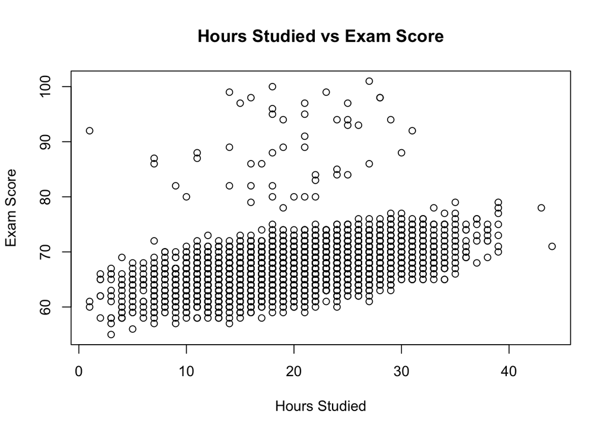

```r
plot(data$Hours_Studied, data$Exam_Score,
     xlab = "Hours Studied",
     ylab = "Exam Score",
     main = "Hours Studied vs Exam Score")
```

# Scatterplot: Attendance vs Exam Score

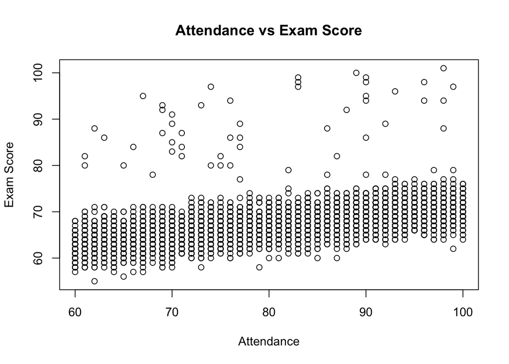

```r
plot(data$Attendance, data$Exam_Score,
     xlab = "Attendance",
     ylab = "Exam Score",
     main = "Attendance vs Exam Score")
```

# Scatterplot: Previous Scores vs Exam Score

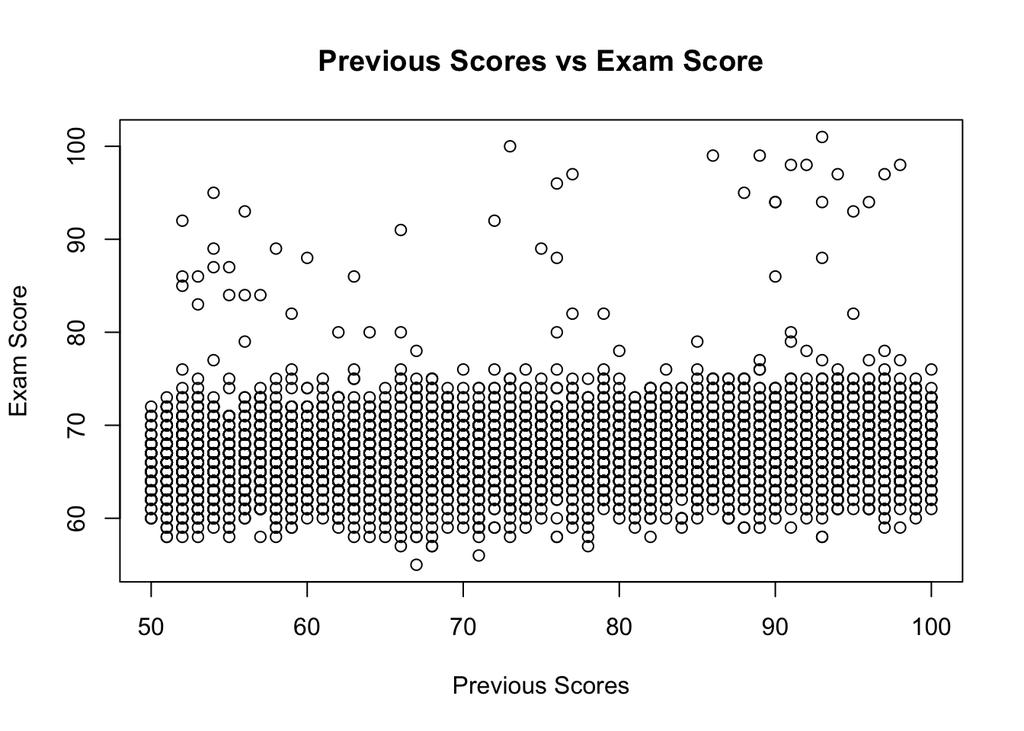

```r
plot(data$Previous_Scores, data$Exam_Score,
     xlab = "Previous Scores",
     ylab = "Exam Score",
     main = "Previous Scores vs Exam Score")
```

# Boxplot: Gender

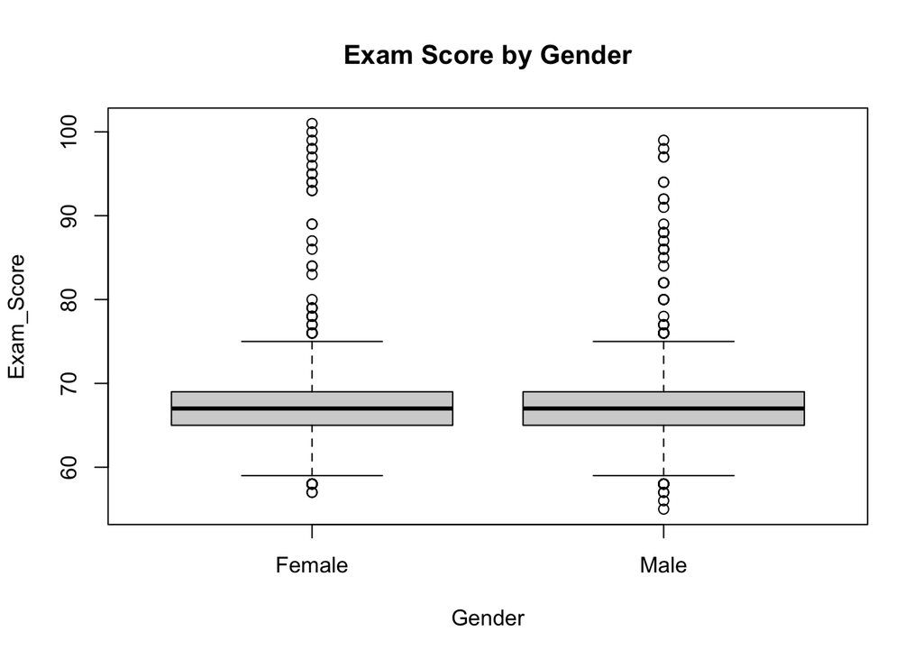

```r
boxplot(Exam_Score ~ Gender, data = data,
        main = "Exam Score by Gender")
```

# Boxplot: Motivation Level

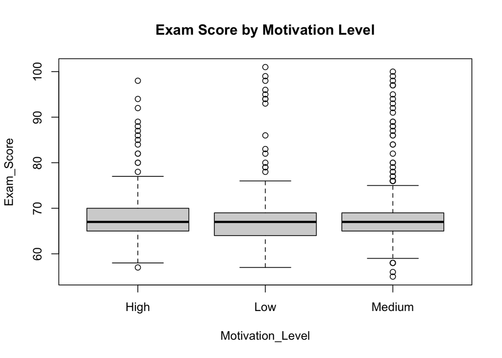

```r
boxplot(Exam_Score ~ Motivation_Level, data = data,
        main = "Exam Score by Motivation Level")
```

# Boxplot: School Type

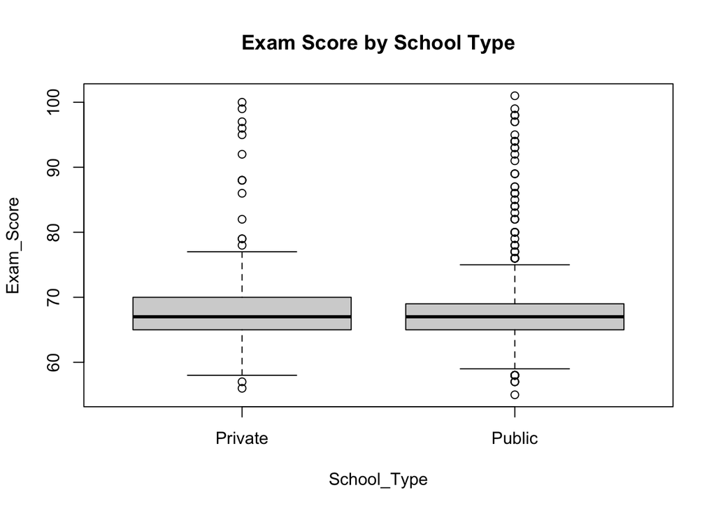

```r
boxplot(Exam_Score ~ School_Type, data = data,
        main = "Exam Score by School Type")
```

Categorical analysis through box plots showed no significant difference by gender, slight differences for motivation and school type. Overall weak categorical effects compared to numeric variables.

```r
# Train-test split
library(caret)
set.seed(123)

train_index <- caret::createDataPartition(data$Exam_Score, p = 0.7, list = FALSE)
train_data <- data[train_index, ]
test_data <- data[-train_index, ]

# Fit final model
model_final <- lm(Exam_Score ~ ., data = train_data)
```

# Residual Plot

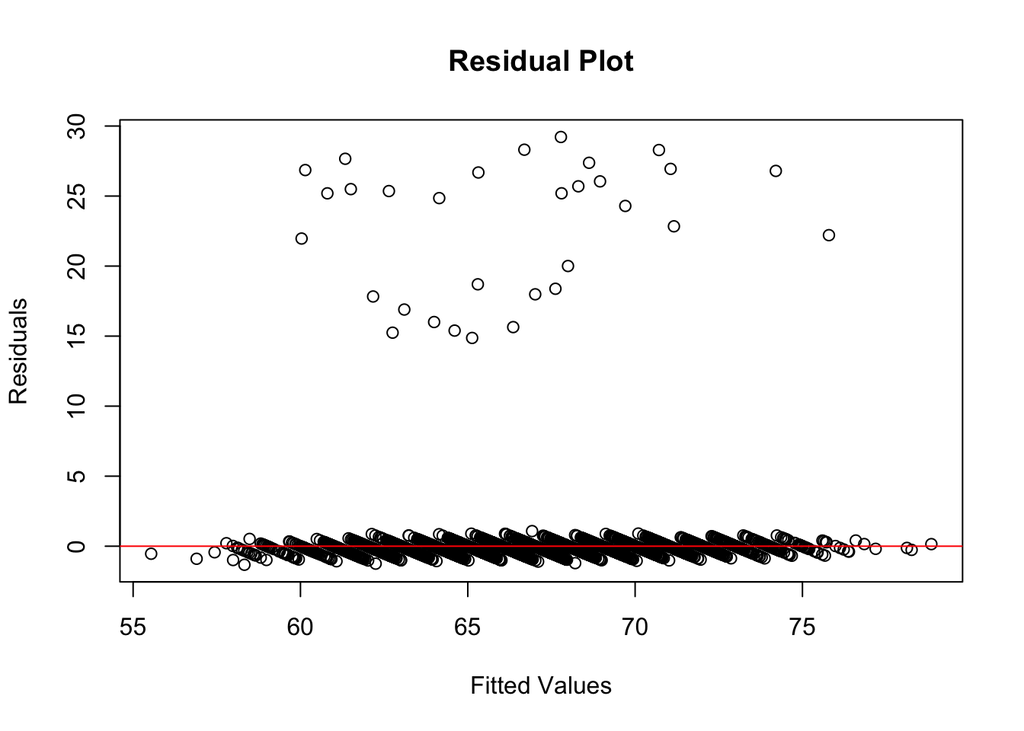

```r
plot(model_final$fitted.values, model_final$residuals,
     xlab = "Fitted Values",
     ylab = "Residuals",
     main = "Residual Plot")
abline(h = 0, col = "red")
```

I also did a residual plot of my full model at the end to look at how well the linear regression model predicts exam score. Most data point are close to zero with a scattering of points in the 15-30 range.

# Discussion

## Residual Plot Interpretation

A residual plot was generated to assess model assumptions. While the majority of residuals are centered around zero, indicating good model fit for most observations, a distinct cluster of large positive residuals is present. Since there is a separate cluster ranging from 15-30 points, there is likely an important missing variable at play. This suggests that the model systematically underestimates exam scores for a subset of observations, indicating that additional variables or nonlinear relationships may not be fully captured by the current linear model. That group likely behaves differently than the rest of the distribution. This could be due to a separate subgroup in my data such as high performers, learning style, disability type etc. This suggests that my model does not fully capture all the patterns in my data and will benefit from more predictor variables. Despite this, the overall distribution of residuals supports the general suitability of the model, with some limitations in capturing extreme values.

## Model Comparison

# Limitations and Future Work

While the linear regression model demonstrates strong predictive performance, several limitations should be acknowledged. First, the model assumes linear relationships between predictors and exam scores. However, the residual analysis revealed a cluster of large positive residuals, suggesting that some nonlinear relationships or interaction effects may not be fully captured. Future work could explore nonlinear models or include interaction terms to better model these complex relationships. Second, the dataset may not include all relevant variables influencing academic performance. The presence of systematically underpredicted observations suggests that the model is missing important factors, such as student engagement, learning styles or external support systems. Incorporating additional variables could improve model accuracy and reduce prediction error. Third, while the model includes many predictors, some variables may be subject to measurement limitations or simplification (categorical groupings of motivation or income). More detailed or continuous measures could provide greater precision and improve model performance. Finally, the model relies on a single linear regression approach. Future research could compare alternative modeling techniques, such as regularization methods or tree-based models, to determine whether predictive performance can be improved while reducing overfitting. Addressing these limitations would enhance the robustness of the analysis and provide a more comprehensive understanding of the factors influencing student exam performance.

# Conclusion

# Bibliography

Grandmaster07. Student Exam Performance Dataset Analysis. Kaggle. https://www.kaggle.com/datasets/grandmaster07/student-exam-performance-dataset-analysis/data James, Gareth, Daniela Witten, Trevor Hastie, and Robert Tibshirani. An Introduction to Statistical Learning. Springer, 2013. “P-Value.” Investopedia. https://www.investopedia.com/terms/p/p-value.asp “Root Mean Squared Error (RMSE).” Investopedia. https://www.investopedia.com/terms/r/rmse.asp “Mean Absolute Error (MAE).” Investopedia. https://www.investopedia.com/terms/m/meanabsoluteerror.asp